# northwell_ds_exercise

## Step 2 - Exploratory Data Analysis

```r
# create a descriptive table for ENTIRE dataset
all_table = heart_data %>%
  tbl_summary(statistic = all_continuous() ~ "{mean} ({sd})")

# split table by outcome (i.e., heart disease)
separate_table = heart_data %>%
  tbl_summary(by = HD,
              statistic = all_continuous() ~ "{mean} ({sd})") %>%
  add_p(test = all_continuous() ~ "t.test",
        test.args = all_tests("t.test") ~ list(var.equal = TRUE))

#output table to word
all_tbl = all_table %>%
  as_flex_table() %>%
  theme_box()

sep_tbl = separate_table %>%
  as_flex_table() %>%
  theme_box()

read_docx() %>%
  body_add_flextable(all_tbl) %>%
  print("table1.docx")

read_docx() %>%
  body_add_flextable(sep_tbl) %>%
  print("table2.docx")
```

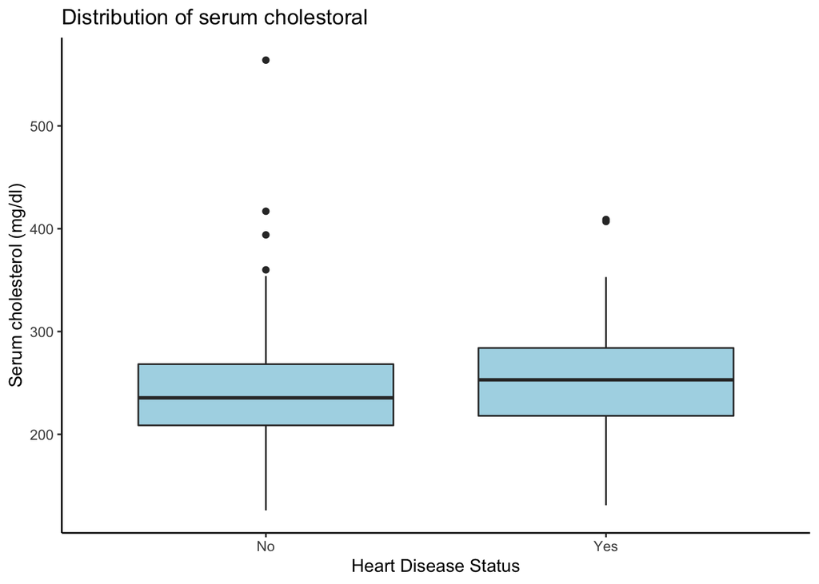

```r
#Quick plot to see distribution of variables
#cholestrol
ggplot(heart_data) +
  geom_boxplot(aes(y=Chol, x=HD), fill = "lightblue") +
  labs(title = "Distribution of serum cholestoral",
       x = "Heart Disease Status",
       y = "Serum cholesterol (mg/dl)") +
  theme_classic()
```

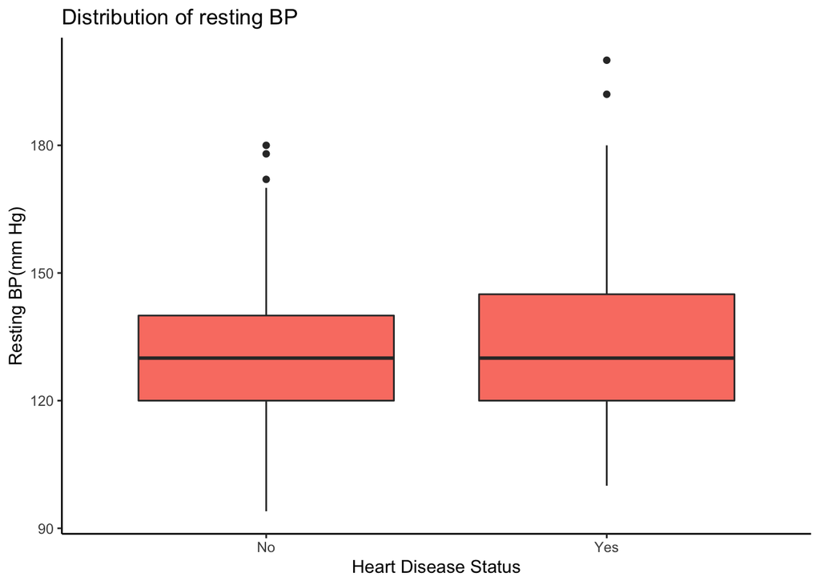

```r
#resting blood pressure
ggplot(heart_data) +
  geom_boxplot(aes(y=RestBP, x=HD), fill = "salmon") +
  labs(title = "Distribution of resting BP",
       x = "Heart Disease Status",
       y = "Resting BP(mm Hg)") +
  theme_classic()
```

## Step 3 - Construct Prediction Models

### Data Partition (70 train: 30 test)

```r
set.seed(100)
train_index <- createDataPartition(y=heart_data$HD, p=0.7, list=FALSE)
train_data <- heart_data[train_index,]
test_data <- heart_data[-train_index,]

# Check if the distribution of heart disease status is similar in the training and test sets
train_data %>%
  group_by(HD) %>%
  summarize(n = n()) %>%
  mutate(percent = n/sum(n))
```

```
## # A tibble: 2 × 3
##   HD        n percent
##   <fct> <int>   <dbl>
## 1 No      112   0.538
## 2 Yes      96   0.462
```

```r
test_data %>%
  group_by(HD) %>%
  summarize(n = n()) %>%
  mutate(percent = n/sum(n))
```

```
## # A tibble: 2 × 3
##   HD        n percent
##   <fct> <int>   <dbl>
## 1 No       48   0.539
## 2 Yes      41   0.461
```

### Model 1: Classification And Regression Trees (CART)

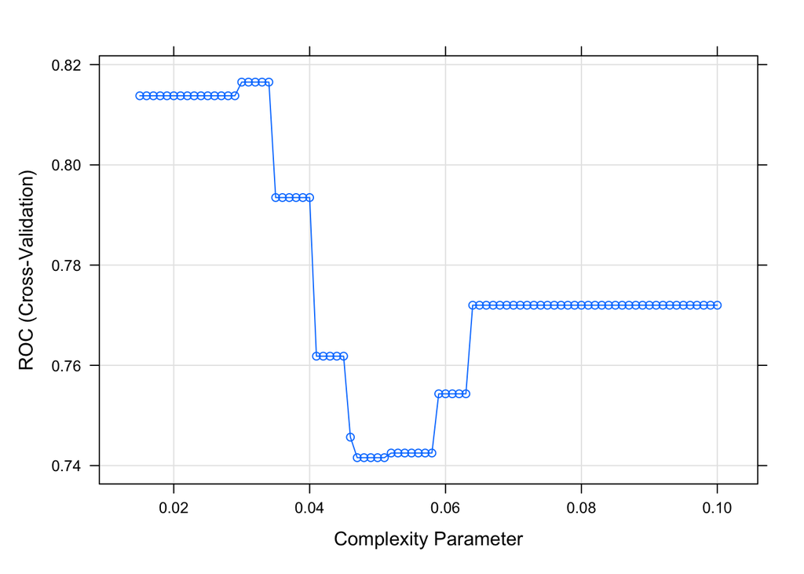

```r
set.seed(100)

#hyperparmeter tuning: cp
cp_grid <- expand.grid(cp = seq(from = 0.015, to = 0.1, by = 0.001))

ctree_heart <- train(HD ~ ., data = train_data, method = "rpart",
           trControl = trainControl("cv", number = 10,
                                    summaryFunction = twoClassSummary,
                                    classProbs = TRUE,
                                    savePredictions = "final"),
           tuneGrid = cp_grid,
           metric = "ROC")

plot(ctree_heart)
```

```r
ctree_heart$bestTune
```

```
##       cp
## 20 0.034
```

### Model 2: Random Forest

```r
set.seed(100)

#hyperparameter tuning: mtry
mtry_grid <- expand.grid(.mtry=c(ncol(train_data)-1, sqrt(ncol(train_data)-1), 0.5*ncol(train_data)-1))

#10-fold cross-validation
rf_heart <- train(HD ~ ., data=train_data, method="rf",
                  trControl=trainControl("cv", number=10,
                                         summaryFunction = twoClassSummary,
                                         classProbs = TRUE,
                                         savePredictions = "final"),
                  tuneGrid=mtry_grid,
                  ntree=100,
                  metric = "ROC")

rf_heart$bestTune
```

```
##       mtry
## 1 3.605551
```

```r
rf_heart$results
```

```
##        mtry       ROC      Sens      Spec      ROCSD    SensSD     SpecSD
## 1  3.605551 0.8909764 0.8136364 0.7388889 0.06829533 0.1548126 0.08768475
## 2  6.000000 0.8779630 0.7856061 0.7288889 0.06467712 0.1875516 0.12049282
## 3 13.000000 0.8673822 0.7863636 0.7177778 0.08256650 0.2097267 0.12060661
```

### Model 3: Elastic Net (regularized regression)

```r
set.seed(100)

en_heart <- train(HD ~ .,data=train_data, method="glmnet", family="binomial", trControl = trainControl("cv", number=10,summaryFunction = twoClassSummary,
                                         classProbs = TRUE,
                                         savePredictions = "final"),
                  tuneLength=10,
                  metric = "ROC")

en_heart$bestTune
```

```
##   alpha     lambda
## 8   0.1 0.04402155
```

```r
en_heart
```

```
## glmnet
##
## 208 samples
##  13 predictor
##   2 classes: 'No', 'Yes'
##
## No pre-processing
## Resampling: Cross-Validated (10 fold)
## Summary of sample sizes: 188, 187, 187, 187, 187, 187, ...
## Resampling results across tuning parameters:
##
##   alpha  lambda        ROC        Sens       Spec
##   0.1    0.0001253749  0.8983165  0.8651515  0.7822222
##   0.1    0.0002896324  0.8983165  0.8651515  0.7822222
##   0.1    0.0006690884  0.8992256  0.8651515  0.7822222
##   0.1    0.0015456810  0.8992256  0.8651515  0.7922222
##   0.1    0.0035707235  0.9010438  0.8469697  0.7922222
##   0.1    0.0082488343  0.9056229  0.8742424  0.8022222
##   0.1    0.0190558772  0.9131481  0.8833333  0.8022222
##   0.1    0.0440215479  0.9158081  0.8840909  0.8033333
##   0.1    0.1016954852  0.9144781  0.8750000  0.8033333
##   0.1    0.2349297607  0.9108249  0.8750000  0.8033333
##   0.2    0.0001253749  0.8983165  0.8651515  0.7822222
##   0.2    0.0002896324  0.8983165  0.8651515  0.7822222
##   0.2    0.0006690884  0.8992256  0.8651515  0.7822222
##   0.2    0.0015456810  0.8992256  0.8651515  0.7922222
##   0.2    0.0035707235  0.9010438  0.8469697  0.7922222
##   0.2    0.0082488343  0.9038047  0.8742424  0.7922222
##   0.2    0.0190558772  0.9122222  0.8833333  0.7822222
##   0.2    0.0440215479  0.9110269  0.8840909  0.7933333
##   0.2    0.1016954852  0.9080808  0.8750000  0.7933333
##   0.2    0.2349297607  0.9080471  0.8750000  0.8033333
##   0.3    0.0001253749  0.8973906  0.8651515  0.7822222
##   0.3    0.0002896324  0.8973906  0.8651515  0.7822222
##   0.3    0.0006690884  0.8992256  0.8651515  0.7822222
##   0.3    0.0015456810  0.8992256  0.8651515  0.7922222
##   0.3    0.0035707235  0.9010438  0.8469697  0.7922222
##   0.3    0.0082488343  0.9038047  0.8651515  0.7922222
##   0.3    0.0190558772  0.9094781  0.8924242  0.7822222
##   0.3    0.0440215479  0.9072727  0.8840909  0.7933333
```

[output cut: 60 more lines]

```
##   0.9    0.1016954852  0.8865488  0.9022727  0.7300000
##   0.9    0.2349297607  0.8625253  0.8674242  0.6255556
##   1.0    0.0001253749  0.8973906  0.8651515  0.7922222
##   1.0    0.0002896324  0.8973906  0.8651515  0.7922222
##   1.0    0.0006690884  0.8992256  0.8651515  0.7922222
##   1.0    0.0015456810  0.9001347  0.8560606  0.7922222
##   1.0    0.0035707235  0.9010438  0.8560606  0.7922222
##   1.0    0.0082488343  0.9001515  0.8742424  0.7822222
##   1.0    0.0190558772  0.8982155  0.8575758  0.7722222
##   1.0    0.0440215479  0.8968687  0.8750000  0.8022222
##   1.0    0.1016954852  0.8828620  0.8939394  0.7300000
##   1.0    0.2349297607  0.7887879  0.9037879  0.3466667
##
## ROC was used to select the optimal model using the largest value.
## The final values used for the model were alpha = 0.1 and lambda = 0.04402155.
```

### Compare model performance

The model with the highest mean cross validation score of AUC will be selected as the final model.

```r
#accuracy
confusionMatrix(ctree_heart) #0.7885
```

```
## Cross-Validated (10 fold) Confusion Matrix
##
## (entries are percentual average cell counts across resamples)
##
##           Reference
## Prediction   No  Yes
##        No  46.2 13.5
##        Yes  7.7 32.7
##
##  Accuracy (average) : 0.7885
```

```r
confusionMatrix(rf_heart) #0.7788
```

```
## Cross-Validated (10 fold) Confusion Matrix
##
## (entries are percentual average cell counts across resamples)
##
##           Reference
## Prediction   No  Yes
##        No  43.7 12.0
##        Yes 10.1 34.1
##
##  Accuracy (average) : 0.7788
```

```r
confusionMatrix(en_heart) #0.8462
```

```
## Cross-Validated (10 fold) Confusion Matrix
##
## (entries are percentual average cell counts across resamples)
##
##           Reference
## Prediction   No  Yes
##        No  47.6  9.1
##        Yes  6.2 37.0
##
##  Accuracy (average) : 0.8462
```

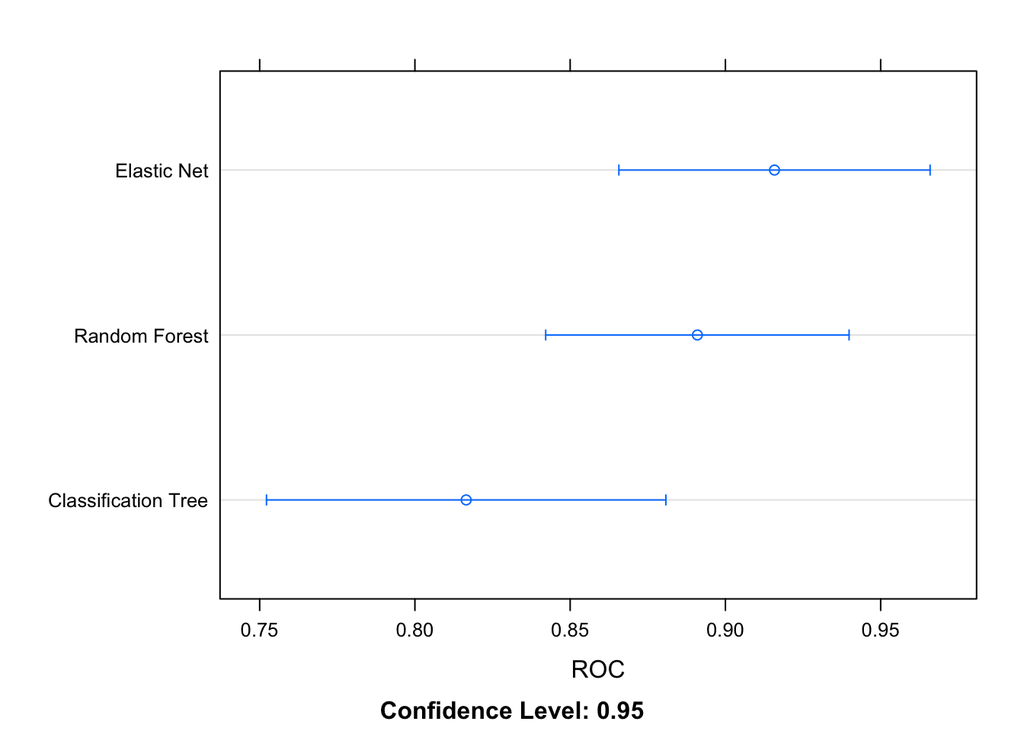

```r
#cross-validated ROC/AUC
mod_comparison <- resamples(list("Classification Tree" = ctree_heart,
                             "Random Forest" = rf_heart,
                             "Elastic Net" = en_heart))

dotplot(mod_comparison, metric = "ROC")
```

```r
#ctree_heart$results %>% pull(ROC) %>% max()
#rf_heart$results %>% pull(ROC) %>% max()
#en_heart$results %>% pull(ROC) %>% max()
```

**Model selection:** Elastic Net is selected as the final model because it had the highest mean cross validation score (CV) for ROC of 0.9158081 and also the highest accuracy of 0.8462. Elastic net performed better than random forest, though there is a lot of overlap in the 95% confidence intervals.

## Step 4 - Model Evaluation

```r
test_pred <- predict(en_heart, newdata = test_data)
test_pred_prob <- predict(en_heart, newdata = test_data, type = "prob")
test_pred_df <- bind_cols(test_data, test_pred_prob)

#Accuracy
confusionMatrix(test_pred, test_data$HD, positive = "Yes")
```

```
## Confusion Matrix and Statistics
##
##           Reference
## Prediction No Yes
##        No  41   8
##        Yes  7  33
##
##                Accuracy : 0.8315
##                  95% CI : (0.7373, 0.9025)
##     No Information Rate : 0.5393
##     P-Value [Acc > NIR] : 6.345e-09
##
##                   Kappa : 0.6602
##
##  Mcnemar's Test P-Value : 1
##
##             Sensitivity : 0.8049
##             Specificity : 0.8542
##          Pos Pred Value : 0.8250
##          Neg Pred Value : 0.8367
##              Prevalence : 0.4607
##          Detection Rate : 0.3708
##    Detection Prevalence : 0.4494
##       Balanced Accuracy : 0.8295
##
##        'Positive' Class : Yes
##
```

```r
#ROC
test_roc <- roc(HD ~ Yes, data = test_pred_df)
```

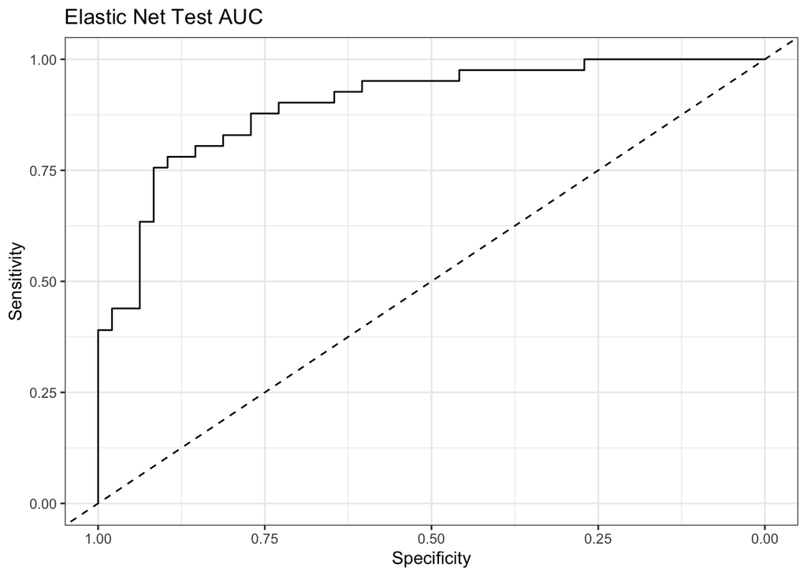

```r
ggroc(test_roc) +
  theme_bw() +
  labs(x = "Specificity", y = "Sensitivity", title = "Elastic Net Test AUC") +
  geom_abline(aes(intercept = 1, slope = 1), linetype = "dashed")
```

```r
# AUC for the final model on the test set
test_auc <- test_roc$auc
test_auc
```

```
## Area under the curve: 0.8989
```

```r
varImp(en_heart)
```

```
## glmnet variable importance
##
##                      Overall
## ChestPainnonanginal 100.0000
## SexMale              92.9826
## ChestPaintypical     69.0585
## Thalnormal           67.4875
## Ca                   65.7787
## ChestPainnontypical  63.5050
## Thalreversable       63.2841
## ExAng1               59.3725
## Slope                37.7896
## Fbs1                 29.5053
## Oldpeak              28.2156
## RestECG              18.2759
## MaxHR                 1.2058
## RestBP                0.7662
## Age                   0.5668
## Chol                  0.0000
```

The AUC for the elastic net model in the test set is **0.8988821.** On the testing set, the accuracy is **0.8315** (95% CI: 0.7373, 0.9025), recall or sensitivity was **0.8049** and precision/PPV was **0.825**.